# Practical Machine learning Course Project

yafei

2018年11月21日

## Course Project

```r
library(lattice)
library(ggplot2)
library(caret)
library(rattle)
rm(list = ls())
Train <- read.csv("pml-training.csv",header = TRUE)
Test <- read.csv("pml-testing.csv",header=TRUE)
```

get some basic idea about the Train data set.

```r
str(Train)
```

```
## 'data.frame':    19622 obs. of  160 variables:
##  $ X                       : int  1 2 3 4 5 6 7 8 9 10 ...
##  $ user_name               : Factor w/ 6 levels "adelmo","carlitos",..: 2 2 2 2 2 2 2 2 2 2 ...
##  $ raw_timestamp_part_1    : int  1323084231 1323084231 1323084231 1323084232 1323084232 1323084232 1323084232 1323084232 1323084232 1323084232 ...
##  $ raw_timestamp_part_2    : int  788290 808298 820366 120339 196328 304277 368296 440390 484323 484434 ...
##  $ cvtd_timestamp          : Factor w/ 20 levels "02/12/2011 13:32",..: 9 9 9 9 9 9 9 9 9 9 ...
##  $ new_window              : Factor w/ 2 levels "no","yes": 1 1 1 1 1 1 1 1 1 1 ...
##  $ num_window              : int  11 11 11 12 12 12 12 12 12 12 ...
##  $ roll_belt               : num  1.41 1.41 1.42 1.48 1.48 1.45 1.42 1.42 1.43 1.45 ...
##  $ pitch_belt              : num  8.07 8.07 8.07 8.05 8.07 8.06 8.09 8.13 8.16 8.17 ...
##  $ yaw_belt                : num  -94.4 -94.4 -94.4 -94.4 -94.4 -94.4 -94.4 -94.4 -94.4 -94.4 ...
##  $ total_accel_belt        : int  3 3 3 3 3 3 3 3 3 3 ...
##  $ kurtosis_roll_belt      : Factor w/ 397 levels "","-0.016850",..: 1 1 1 1 1 1 1 1 1 1 ...
##  $ kurtosis_picth_belt     : Factor w/ 317 levels "","-0.021887",..: 1 1 1 1 1 1 1 1 1 1 ...
##  $ kurtosis_yaw_belt       : Factor w/ 2 levels "","#DIV/0!": 1 1 1 1 1 1 1 1 1 1 ...
```

[output cut: 86 more lines]

as I find there is a lot of NA values on some obervation. We will excute those variables in the data set and my final model.

```r
indColToRemove <- which(colSums(is.na(Train) |Train=="")>0.9*dim(Train)[1])
Trainclean <- Train[,-indColToRemove]
Trainclean <- Trainclean[,-c(1:7)]
indColToRemove <- which(colSums(is.na(Test) |Test=="")>0.9*dim(Test)[1])
TestClean <- Test[,-indColToRemove]
TestClean <- TestClean[,-1]
```

after clean the dataset, I am going to creat a traning data set and test data set.

```r
set.seed(66666)
inTrain <- createDataPartition(Trainclean$classe, p=0.7, list = FALSE)
Training <- Trainclean[inTrain,]
Testing <- Trainclean[-inTrain,]
```

In this class, I learned three different models: classification tree, random forest and gradient boosting method. I will try all of them and I will also use the cross-validation to improve the efficienty of each model. ## classification tree

```r
library(rpart)
model_ct <- train(classe~., data = Training, method="rpart")
```

it takes very very long to get the result, so I am going ton control the computational nuances of the train function.

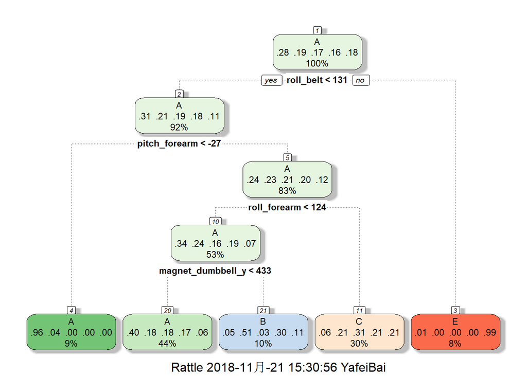

```r
library(parallel)
library(foreach)
library(iterators)
library(doParallel)
cluster <- makeCluster(detectCores() - 1)
registerDoParallel(cluster)
ctr1 <- trainControl(method = "cv", number=5, allowParallel = TRUE)
model_ct <- train(classe~., data = Training, method="rpart", trControl=ctr1)
fancyRpartPlot(model_ct$finalModel)
```

```r
trainresult <- predict(model_ct, newdata = Testing)
result <- confusionMatrix(Testing$classe, trainresult)
result$table
```

```
##           Reference
## Prediction    A    B    C    D    E
##          A 1499   38  134    0    3
##          B  480  305  354    0    0
##          C  484   21  521    0    0
##          D  417  163  384    0    0
##          E  140   72  376    0  494
```

```r
result$overall
```

```
##       Accuracy          Kappa  AccuracyLower  AccuracyUpper   AccuracyNull
##      0.4790144      0.3202129      0.4661793      0.4918704      0.5131691
## AccuracyPValue  McnemarPValue
##      0.9999999            NaN
```

the accuracy is 0.479 which is very low. So the classification is not a good way to predict ## random forests

```r
library(randomForest)
model_rf <- train(classe~., data=Training, method="rf", trControl=ctr1)
model_rf
```

```
## Random Forest
##
## 13737 samples
##    52 predictor
##     5 classes: 'A', 'B', 'C', 'D', 'E'
##
## No pre-processing
## Resampling: Cross-Validated (5 fold)
## Summary of sample sizes: 10990, 10990, 10990, 10988, 10990
## Resampling results across tuning parameters:
##
##   mtry  Accuracy   Kappa
##    2    0.9910463  0.9886728
##   27    0.9917014  0.9895014
##   52    0.9866056  0.9830553
##
## Accuracy was used to select the optimal model using the largest value.
## The final value used for the model was mtry = 27.
```

```r
predict_rf <- predict(model_rf,Testing)
```

```r
result_rf <- confusionMatrix(Testing$classe,predict_rf)
result_rf$table
```

```
##           Reference
## Prediction    A    B    C    D    E
##          A 1672    1    1    0    0
##          B    8 1130    1    0    0
##          C    0    2 1020    4    0
##          D    0    0    4  959    1
##          E    0    0    2   10 1070
```

by the result, only a few variables are out of the random forests model

## gradient boosting method

```r
model_gbm <- train(classe~., data=Training, method="gbm", trControl=ctr1)
model_gbm
```

```
## Stochastic Gradient Boosting
##
## 13737 samples
##    52 predictor
##     5 classes: 'A', 'B', 'C', 'D', 'E'
##
## No pre-processing
## Resampling: Cross-Validated (5 fold)
## Summary of sample sizes: 10990, 10990, 10990, 10990, 10988
## Resampling results across tuning parameters:
##
##   interaction.depth  n.trees  Accuracy   Kappa
##   1                   50      0.7543132  0.6884411
##   1                  100      0.8207027  0.7731161
##   1                  150      0.8529512  0.8139417
##   2                   50      0.8516411  0.8120608
##   2                  100      0.9036900  0.8780903
##   2                  150      0.9297513  0.9110939
##   3                   50      0.8911693  0.8622095
##   3                  100      0.9397244  0.9237188
##   3                  150      0.9592340  0.9484173
##
## Tuning parameter 'shrinkage' was held constant at a value of 0.1
##
## Tuning parameter 'n.minobsinnode' was held constant at a value of 10
## Accuracy was used to select the optimal model using the largest value.
## The final values used for the model were n.trees = 150,
##  interaction.depth = 3, shrinkage = 0.1 and n.minobsinnode = 10.
```

```r
predict_gbm <- predict(model_gbm, Testing)
result_gbm <- confusionMatrix(Testing$classe,predict_gbm)
result_gbm$table
```

```
##           Reference
## Prediction    A    B    C    D    E
##          A 1647   18    3    3    3
##          B   31 1067   38    3    0
##          C    0   26  980   16    4
##          D    2    2   19  935    6
##          E    4    6   16   17 1039
```

## Model Selection

It is very clear to ses that the Random Forest produces the model with the highest accuracy more than 99%.

## Prediction

```r
final_pred <- predict(model_rf, Test, type="raw")
final_pred
```

```
##  [1] B A B A A E D B A A B C B A E E A B B B
## Levels: A B C D E
```